# Network_workshop

### Communities and modules

Graph **communities structure** is defined if the nodes of the network can be easily grouped into (potentially overlapping) sets of nodes such that each set of nodes is densely connected internally. **Modularity** is always used as a measure the strength of division of a network into community for optimization methods in detecting community structure in networks.

There are many algorithms to cluster graph to communities.

- **cluster_edge_betweenness** a hierarchical decomposition process where edges are removed in the decreasing order of their edge betweenness scores.
- **cluster_optimal** - a top-down hierarchical approach that optimizes the modularity function
- **cluster_walktrap** - an approach based on random walks
- **cluster_fast_greedy**
- **cluster_label_prop**
- **cluster_leading_eigen**
- **cluster_Louvain**
- **cluster_spinglass**

For more information to determine which cluster method to use can be found in the discussion https://stackoverflow.com/questions/9471906/what-are-the-differences-between-community-detection-algorithms-in-igraph

```r
# cluster graph using walktrap method, turn a ”communities” object
wtc <- cluster_walktrap(gr)
wtc
```

```
## IGRAPH clustering walktrap, groups: 3, mod: 0.33
## + groups:
##   $`1`
##   [1]  1  3  8  9 10
##
##   $`2`
##   [1] 2 5 6
##
##   $`3`
##   [1] 4 7
##
```

```r
# find membership for each vertice
membership(wtc)
```

```
##  [1] 1 2 1 3 2 2 3 1 1 1
```

```r
# calculate modularity for walktrap clustering on this graph
modularity(wtc)
```

```
## [1] 0.3305785
```

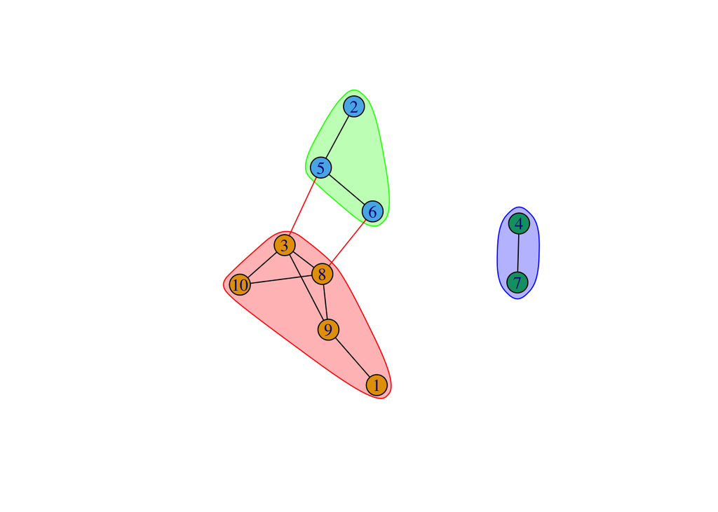

```r
# plot community
coords <- layout_(gr, nicely())
plot(wtc, gr, layout=coords)
```

# Network visualization

Network visualization are supported by two aspects — the aestheic part of network elements (aka, vertices and edges) and layout of network. There are multiple packages available for these aspects. I will focus on the basic igraph plot (more like base R plot) and the application of ggraph (comparable to ggplot2).

In this part, we will go back to use actor graph data.

```r
actors <- data.frame(
  name=c("Alice", "Bob", "Cecil", "David","Esmeralda"),
  age=c(48,33,45,34,21),
  gender=c("F","M","F","M","F"))
relations <- data.frame(
  from=c("Bob", "Cecil", "Cecil", "David","David", "Esmeralda"),
  to=c("Alice", "Bob", "Alice", "Alice", "Bob", "Alice"),
  same.dept=c(FALSE,FALSE,TRUE,FALSE,FALSE,TRUE),
  friendship=c(4,5,5,2,1,1),
  advice=c(4,5,5,4,2,3)
  )
g <- graph_from_data_frame(relations, directed=TRUE, vertices=actors)
```

## Aesthetics of network elements

The aesthetics of both vertices and edges can be manipulated at color, transparency. Specially for vertices, we can also manipulate its shape, size and fill. For edges, we can manipulate its width/thickness, linetype, arrow and so on. Here, use simple example “actors” to show you how to present aesthetics using `igraph` default plot and `ggraph`

### Vertice aesthetics

Specify aesthetics in vertex attribute

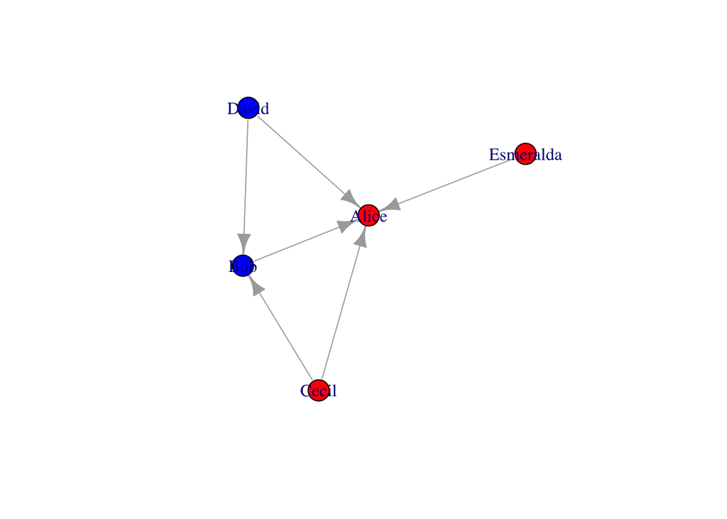

```r
# make female and male color different
v = igraph::as_data_frame(g, what="vertice") %>% tbl_df %>%
  mutate(color=case_when(gender=="F" ~ "red", gender=="M" ~ "blue"))
g = g %>% set_vertex_attr("color", value=v$color)
plot(g)
```

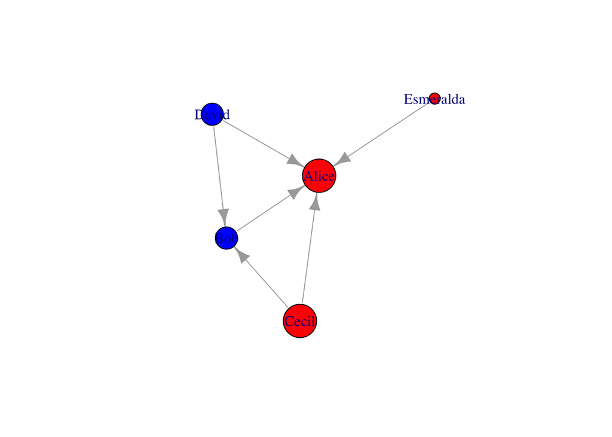

```r
# make age as size
v = v %>%
  mutate(size=case_when(age < 30 ~ 10, age < 40 & age >30 ~ 20, age > 40 ~ 30))
g = g %>% set_vertex_attr("size", value=v$size)
plot(g)
```

The methods mentioned above can also be done by specify in `plot()`. One quick example below show the shape aesthetics. Check igraph valid shape names by `names(igraph:::.igraph.shapes)`

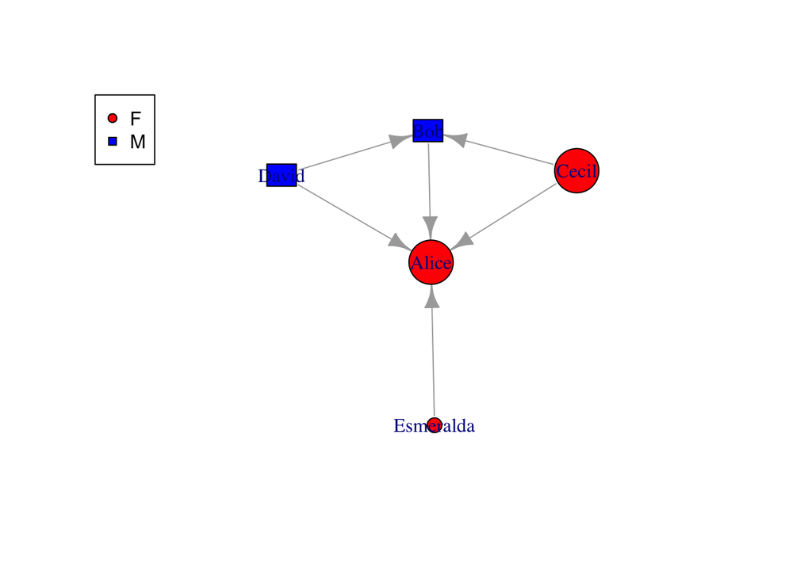

```r
# make gender as shape
v = v %>%
  mutate(shape=case_when(gender=="F" ~ "circle", gender=="M" ~ "rectangle"))

plot(g, vertex.shape=v$shape)
legend('topleft',legend=unique(v$gender),pch=c(21, 22),pt.bg=c("red","blue"))
```

Be aware that the aesthetics specified by attributes can be overwritten by specifying in `plot()`. In addition, those aesthetics can also be used to apply to all vertices like `plot(g, vertex.shape="rectangle")`. The attributes to be manipulated in igraph (using base R) are limited. To find all the plotting attributes, try `?plot.igraph` or go to https://igraph.org/r/doc/plot.common.html

We can also draw attention to certain nodes by `mark.groups` in plot

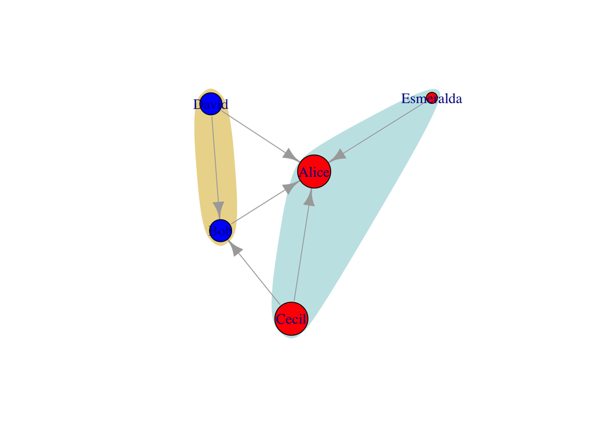

```r
# mark dept
g = g %>% set_vertex_attr("dept",value=c("sale","IT","sale","IT","sale")) %>%
  set_edge_attr("same.dept",value=c(F,F,T,F,T,T))
v = igraph::as_data_frame(g, "vertices")
plot(g,
     mark.groups=list(
       unlist(v %>% filter(dept=="sale") %>% select(name)),
       unlist(v %>% filter(dept=="IT") %>% select(name))
       ),
     mark.col=c("#C5E5E7","#ECD89A"), mark.border=NA)
```

`ggraph` is a ggplot version of graph plotting. Using graph object as input, it can convert vertice attributes to plot attribute automatically or manually.

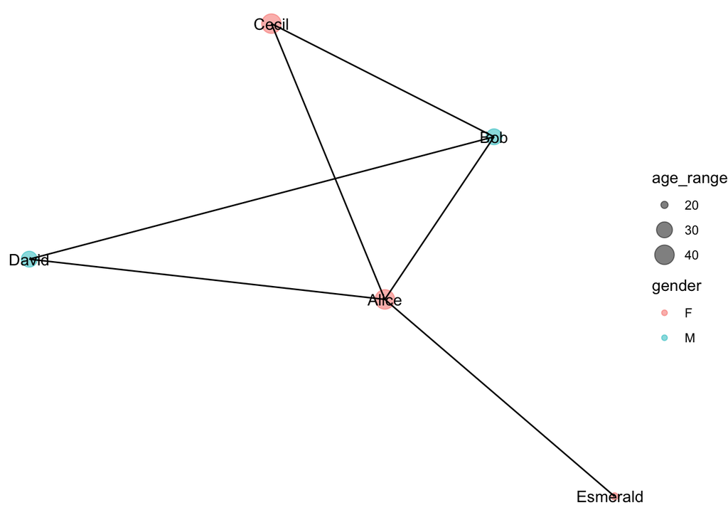

```r
v = v %>%
  mutate(age_range=case_when(age < 30 ~ 20, age < 40 & age >30 ~ 30, age > 40 ~ 40))
g = g %>% set_vertex_attr("age_range", value=v$age_range)
ggraph(g, layout = "kk") +
  geom_node_point(aes(size=age_range, color=gender), alpha=0.5) +
  geom_node_text(aes(label=name)) +
  geom_edge_link() +
  scale_size_continuous(breaks=c(20,30,40), range = c(2, 6)) +
  theme_void()
```

Almost all the ggplots theme, scale functions are available for ggraph. More details refer to https://www.rdocumentation.org/packages/ggraph/versions/1.0.2

### Edge aesthetics

Similar to vertex aesthetics, edge plotting aesthetics can be manipulated both igraph default plotting and ggraph plotting

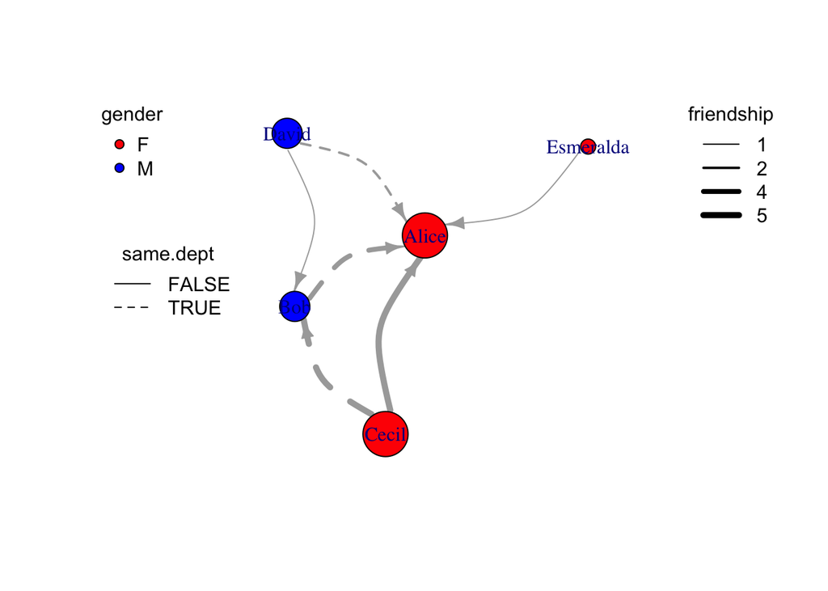

```r
# use linetype present whether come from same department, and line width presents friendship
e = igraph::as_data_frame(g, what="edges") %>% tbl_df %>%
  mutate(width=friendship) %>%
  mutate(lty=ifelse(same.dept,1,2))
plot(
  g %>% set_edge_attr("width",value=e$width) %>% set_edge_attr("lty",value=e$lty),
  edge.arrow.size=0.8,
  edge.curved=T
)
legend("topleft", legend=unique(v$gender),pch=21,pt.bg=c("red","blue"), title="gender", box.lty=0)
legend("left",legend=unique(e$same.dept),lty=c(1,2), title = "same.dept",box.lty=0)
legend("topright", legend=sort(unique(e$friendship)), lwd=sort(unique(e$friendship)), title="friendship", box.lty=0)
```

Using ggraph to show edges attribute is much easier.

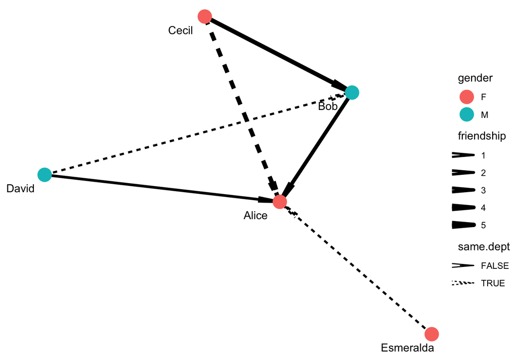

```r
ggraph(g, layout="kk") +
  geom_edge_link(aes(edge_width=friendship, edge_linetype=same.dept), arrow = arrow(angle=5, length = unit(0.3, "inches"))) +
  geom_node_point(aes(color=gender), size=6) +
  geom_node_text(aes(label=name), nudge_y = -0.1, nudge_x = -0.1) +
  scale_edge_width(range = c(1, 2)) +
  theme_void()
```

### Facet

One big advantage of ggraph is using facet. It can be `facet_edges` or `facet_nodes` or `facet_graph`. Here I will only show example of `facet_nodes`.

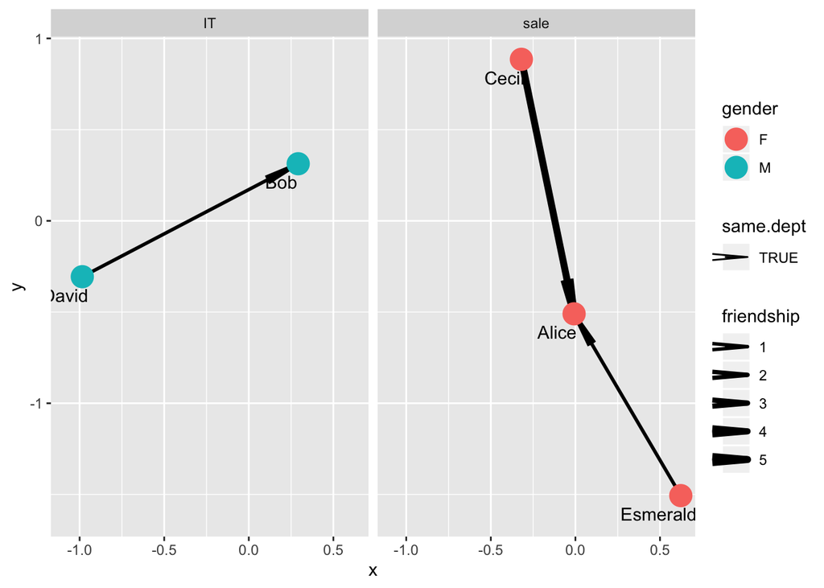

```r
g = g %>% set_vertex_attr("dept",value=c("sale","IT","sale","IT","sale")) %>%
  set_edge_attr("same.dept",value=c(F,F,T,F,T,T))

#  facet based on the dept
ggraph(g, layout="kk") +
  facet_nodes(~dept, drop = F) +
  geom_edge_link(aes(edge_width=friendship, linetype=same.dept), arrow = arrow(angle=5, length = unit(0.3, "inches"))) +
  geom_node_point(aes(color=gender), size=6) +
  geom_node_text(aes(label=name), nudge_y = -0.1, nudge_x = -0.1) +
  scale_edge_width(range = c(1, 2))
```

## Layout

There are many layouts available for both igraph and ggraph pacakges. Igraph provides a huge amount of layouts. https://igraph.org/r/doc/layout_.html

- **Standard layouts**
  - **bipartite**: minimize edge-crossings in a simple two-row (or column) layout for bipartite graphs.
  - **star**: place one node in the center and the rest equidistantly around it. `as_star()`
  - **circle**: place nodes in a circle in the order of their index. Consider using layout_igraph_linear with circular=TRUE for more control. `in_circle()`
  - **nicely**: default, tries to pick an appropriate layout. `nicely`
  - **dh**: uses Davidson and Harels simulated annealing algorithm to place nodes. `with_dh()`
  - **gem**: place nodes on the plane using the GEM force-directed layout algorithm. `with_gem`
  - **graphopt**: uses the Graphopt algorithm based on alternating attraction and repulsion to place nodes. `with_graphopt()`
  - **grid**:place nodes on a rectangular grid. `on_grid()`
  - **mds**: perform a multidimensional scaling of nodes using either the shortest path or a user supplied distance. `with_mds()`
  - **sphere**: place nodes uniformly on a sphere - less relevant for 2D visualizations of networks. `with_sphere()`
  - **randomly**: places nodes uniformly random. `randomly`
  - **fr**: places nodes according to the force-directed algorithm of Fruchterman and Reingold. `with_fr()`
  - **kk**: uses the spring-based algorithm by Kamada and Kawai to place nodes. `with_kk()`
  - **drl**: uses the force directed algorithm from the DrL toolbox to place nodes. `with_drl()`
  - **lgl**: uses the algorithm from Large Graph Layout to place nodes. See with_lgl `with_lgl()`
- **Hierarchical layouts**
  - **tree**: uses the Reingold-Tilford algorithm to place the nodes below their parent with the parent centered above its children. `as_tree()`
  - **sugiyama**: designed for directed acyclic graphs (that is, hierarchies where multiple parents are allowed) it minimizes the number of crossing edges.

Here we are going to show an example how to switch standard layout using the same data.

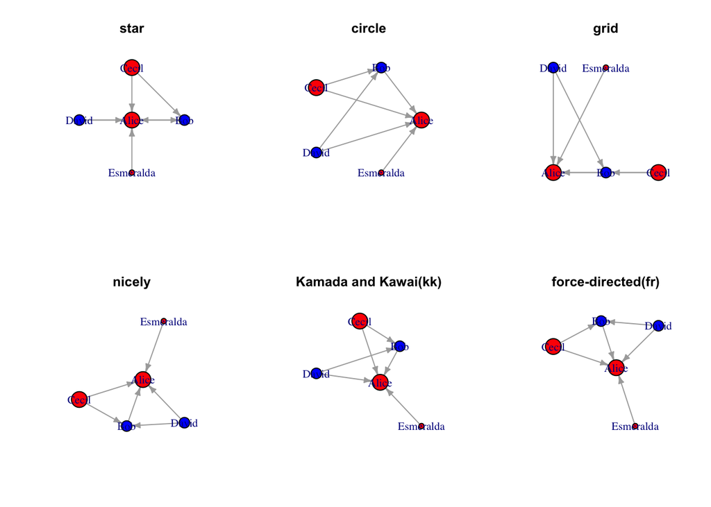

```r
par(mfrow=c(2,3))
# star layout -- help determine center
coords <- layout_(g, as_star())
plot(g, layout = coords, edge.arrow.size=0.4)
title("star")

# circle layout
coords <- layout_(g, in_circle())
plot(g, layout = coords, edge.arrow.size=0.4)
title("circle")

# grid
coords <- layout_(g, on_grid())
plot(g, layout = coords, edge.arrow.size=0.4)
title("grid")

# nicely
coords <- layout_(g, nicely())
plot(g, layout = coords, edge.arrow.size=0.4)
title("nicely")

# kk
coords <- layout_(g, with_kk())
plot(g, layout = coords, edge.arrow.size=0.4)
title("Kamada and Kawai(kk)")

# fr
coords <- layout_(g, with_fr())
plot(g, layout = coords, edge.arrow.size=0.4)
title("force-directed(fr)")
```

Hierarchical layouts can plot data in layer. Here show example how to use sugiyama layout.

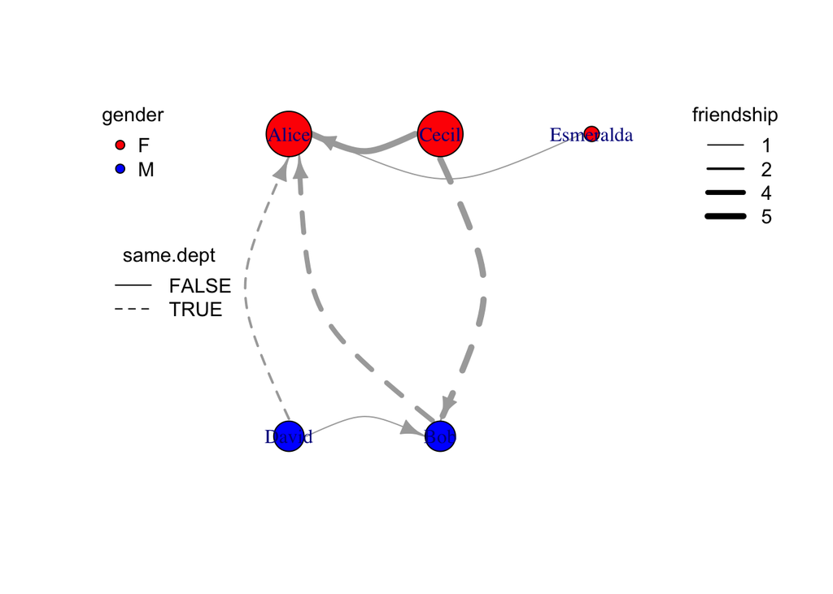

```r
# make different dept nodes at different node
g = g %>% set_vertex_attr("dept",value=c("sale","IT","sale","IT","sale")) %>%
  set_edge_attr("same.dept",value=c(F,F,T,F,T,T))

v = igraph::as_data_frame(g, "vertices") %>% tbl_df %>%
  mutate(layer=ifelse(dept=="sale",1,2))

e = igraph::as_data_frame(g, what="edges") %>% tbl_df %>%
  mutate(width=friendship) %>%
  mutate(lty=ifelse(same.dept,1,2))

g = g %>% set_edge_attr("width",value=e$width) %>% set_edge_attr("lty",value=e$lty)

lay1 <-  layout_with_sugiyama(g, layers=v$layer, attributes="all")

plot(lay1$extd_graph, edge.curved=T)
legend("topleft", legend=unique(v$gender),pch=21,pt.bg=c("red","blue"), title="gender", box.lty=0)
legend("left",legend=unique(e$same.dept),lty=c(1,2), title = "same.dept",box.lty=0)
legend("topright", legend=sort(unique(e$friendship)), lwd=sort(unique(e$friendship)), title="friendship", box.lty=0)
```

`ggraph` can use all the layout mentioned above by specifying it in `ggraph(g, layout=...)`. Besides, ggraph has addtional useful layout.

- dendrogram: dendrogram layout not only take in graph object but also dendrogram object (`as.dendrogram(hclust(dist(...)))`). ggraph will automatically convert dendrogram to igraph by `den_to_igraph`. It ususally plots using `geom_edge_diagonal()` or `geom_edge_elbow()`.

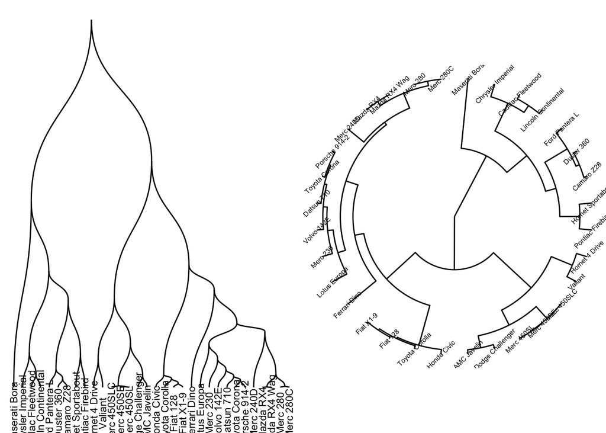

```r
den <- as.dendrogram(hclust(dist(mtcars)))
p1 = ggraph(den, 'dendrogram') +
    geom_edge_diagonal() +
    geom_node_text(aes(label=label), angle=90, nudge_y=-30, size=3) +
  theme_void()
p2 = ggraph(den, 'dendrogram', circular = TRUE) +
    geom_edge_elbow() +
    geom_node_text(aes(label=label), angle=45, size=2) +
  coord_fixed()+
  theme_void()
grid.arrange(p1,p2,ncol=2)
```

- hive: make nodes group into a axis and connecting axis instead.

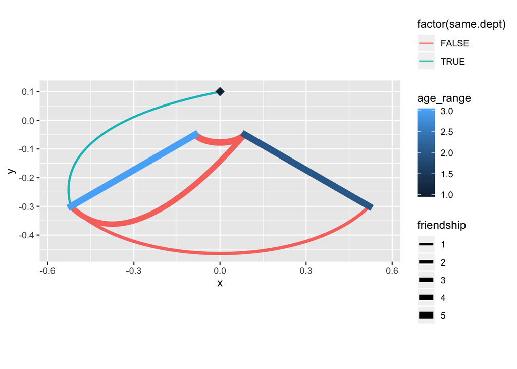

```r
V(g)$age_range = factor(V(g)$age_range)

ggraph(g, 'hive', axis = 'age_range', sort.by = 'age') +
    geom_edge_hive(aes(color = factor(same.dept), edge_width=friendship)) +
    geom_axis_hive(aes(color = age_range), size = 3, label = FALSE) +
    coord_fixed() +
  scale_edge_width(range=c(1,3))
```

- linear: make nodes only the same line so that arc connections were made.

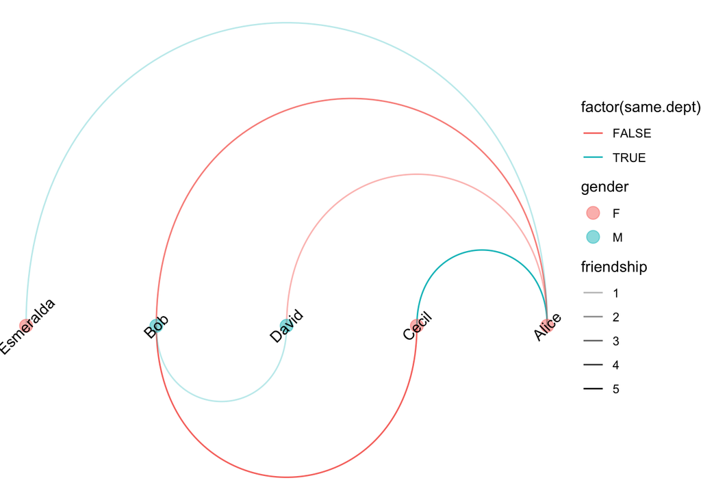

```r
ggraph(g, layout = 'linear', sort.by = 'age') +
    geom_edge_arc(aes(color = factor(same.dept), edge_alpha=friendship)) +
  geom_node_point(aes(color=gender), size=4, alpha=0.5) +
  geom_node_text(aes(label=name), angle=45) +
  theme_void() +
  scale_edge_alpha(range=c(0.3,1))
```

More functions about ggraph refer to https://www.rdocumentation.org/packages/ggraph/versions/1.0.2